```python
from utils import *
from datetime import datetime
import pandas as pd
```

# Methodology

Let $N$ be the number of Value-at-Risk (VaR) levels to be tested. Define the $\alpha$-levels by

$$ \alpha_j = \alpha_1 + (j-1)\frac{1-\alpha_1}{N}, \qquad j = 1,\ldots,N+1, $$

with $\alpha_0 = 0$ and $\alpha_{N+1} = 1$.

Given $n$ samples from the probability distribution $F$, compute the corresponding empirical quantiles $\hat q_{\alpha_j}$.

## Partitioning the sample

Define the sets

$$ A_j(\mathbf{L}) = {L_t : \hat{q}_{\alpha_{j-1}} < L_t \le \hat{q}_{\alpha_j}, ; t = 1, \ldots, n}, \qquad j = 1,\ldots,N+1. $$

By construction the intervals are equally spaced:

$$ \alpha_j - \alpha_{j-1} = \alpha_{j+1} - \alpha_j \quad\text{for } j \in {2,\ldots,N+1}. $$

Thus each set $A_j(\mathbf{L})$ contains $k$ elements where

$$ k = \frac{n(1-\alpha_1)}{N}. $$

Write the ordered elements in each interval as

$$ A_j(\mathbf{L}) = {L_j^{(1)}, L_j^{(2)}, \ldots, L_j^{(k)}}, $$

with $L_j^{(1)} \le L_j^{(2)} \le \cdots \le L_j^{(k)}$.

## Barycenters

The barycenter is computed componentwise across bins $j=2,\ldots,N+1$:

$$ \boldsymbol{\mathcal{Y}}=(\mathcal{Y}_1,\ldots,\mathcal{Y}_k), \qquad \mathcal{Y}_r = \frac{1}{N}\sum_{j=2}^{N+1} L_j^{(r)}, \quad r = 1,\ldots,k. $$

Similarly, compute barycenters for samples from distribution $G$ and denote them

$$ \boldsymbol{\mathcal{Z}}=(\mathcal{Z}_1,\ldots,\mathcal{Z}_k). $$

## 1D Wasserstein distance

The 1D Wasserstein distance between the barycenters $\mathcal{Y} = (Y_1,\ldots,Y_k)$ and $\mathcal{Z} = (Z_1,\ldots,Z_k)$ is

$$ W(\mathcal{Y},\mathcal{Z}) = \frac{1}{n} \sum_{i=1}^k |Y_{(i)} - Z_{(i)}|. $$

If $\mathcal{Y}$ and $\mathcal{Z}$ are not of equal length, interpolation is used (this matches the function `wasserstein_1d_scipy`).

### Feasibility constraint

The procedure is valid when $k \ge 1$, i.e.

$$ N \le n(1-\alpha_1) \quad\Longleftrightarrow\quad n \ge \frac{N}{1-\alpha_1}. $$

These constraints ensure each interval contains enough samples for meaningful barycenter computation, controlled by $\alpha_1$. For example, with $\alpha_1 = 0.975$ and $n = 250$, the maximum feasible $N$ is 6; for $N = 64$ the minimum feasible $n$ is 2560.

#### Reference tables

Maximum feasible $N$ for given $n$:

| $n$ | max $N$ |
| --- | --- |
| 250 | 6 |
| 500 | 12 |
| 1000 | 25 |
| 2000 | 50 |

Minimum required $n$ for given $N$:

| $N$ | min $n$ |
| --- | --- |
| 1 | 40 |
| 2 | 80 |
| 4 | 160 |
| 8 | 320 |
| 16 | 640 |
| 32 | 1280 |
| 64 | 2560 |

### Note on interpolation and unequal bin sizes

If bins have unequal counts, the current approach takes the minimum number of points across bins and computes the barycenter using those minima — this discards data from larger bins. An alternative is to interpolate or resample the order statistics so each bin yields equal-length vectors before averaging; this preserves more information.

# Simulation Procedure

**Hypotheses**

- **Null hypothesis ($H_0$)**: $G = F$ (no difference; distance below critical value)
- **Alternative hypothesis ($H_1$)**: $G \ne F$ (distributions differ; distance above critical value)

**Steps**

1. Draw $n$ samples from $F$.
2. Fix $N$ and $\alpha_1$ to determine the quantile levels ${\alpha_j}$.
3. Determine the critical value $B_{\text{crit}}$ by sampling under the null hypothesis ($G=F$), computing the Wasserstein distance for each replication, and taking the $(1-0.05)$-quantile of the resulting distances.
4. For each replication in the power study:
   - Draw $n$ samples from $G$.
   - Partition each sample into $N$ intervals using the quantiles ${\alpha_j}$, provided the feasibility constraints are met.
   - Compute barycenters $\boldsymbol{\mathcal{Y}}$ and $\boldsymbol{\mathcal{Z}}$ for $F$ and $G$.
   - Calculate the Wasserstein distance $W(\boldsymbol{\mathcal{Y}},\boldsymbol{\mathcal{Z}})$.
   - If $W(\boldsymbol{\mathcal{Y}},\boldsymbol{\mathcal{Z}}) > B_{\text{crit}}$, reject $H_0$.
5. Return the empirical rejection rate over all replications for each configuration $(n, N, G)$.

```python
f_samples = g_dists["Normal"].rvs(2000)
```

## Wasserstein Distances Calculation

```python
output_type = 'list'  # 'list' or 'summary'
# seed = 12
seed = np.random.randint(1, 100000)
timestamp = f"{datetime.now().strftime("%Y%m%d_%H%M%S")}_{seed}"

results = run_wasserstein_barycentre_simulations(f_sample=f_samples, N_list=[1,2,4, 8], N_replications=1000, verbose=False, output_type=output_type, seed=seed)
results_df = pd.DataFrame(results)

print(results_df.drop(columns=['W_list']).set_index(['G', 'n', 'N']).to_string(float_format="%.4f"))

# save to csv
output_filename = f"results/bary_meth1_{timestamp}.csv"
results_df.drop(columns=['W_list']).to_csv(output_filename, index=False)
```

```
seed: 50616
               W_mean  W_var  W_min   W_max
G      n    N
Normal 250  1  0.2111 0.0112 0.0356  0.8329
            2  0.1859 0.0119 0.0078  0.7442
            4  0.1601 0.0148 0.0001  0.6612
            8     NaN    NaN    NaN     NaN
       500  1  0.1591 0.0071 0.0326  0.5631
            2  0.1501 0.0094 0.0180  0.6022
            4  0.1438 0.0100 0.0057  0.5613
            8  0.1391 0.0121 0.0003  0.6589
       1000 1  0.1183 0.0020 0.0398  0.3389
            2  0.1018 0.0026 0.0224  0.3196
            4  0.0938 0.0033 0.0130  0.3478
            8  0.0888 0.0033 0.0049  0.3192
```

[output cut: 52 more lines]

#### Plot of the mean Wasserstein distances

y-axis denotes 100 times the wasserstein distance as calculated above

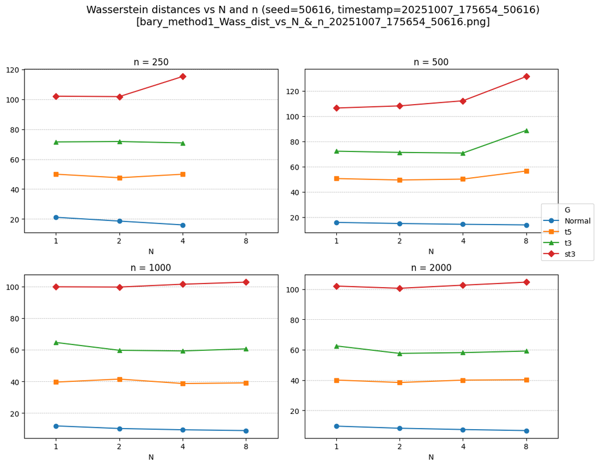

```
'bary_method1_Wass_dist_vs_N_&_n_20251007_175654_50616.png'
```

```python
plot_wass_distances_mean(results_df, filename=f"bary_method1_Wass_dist_vs_N_&_n_{timestamp}.png", title = f"Wasserstein distances vs N and n (seed={seed}, timestamp={timestamp})")
```

#### Plot of the spread

y-axis denotes 100 times the wasserstein distance as calculated above

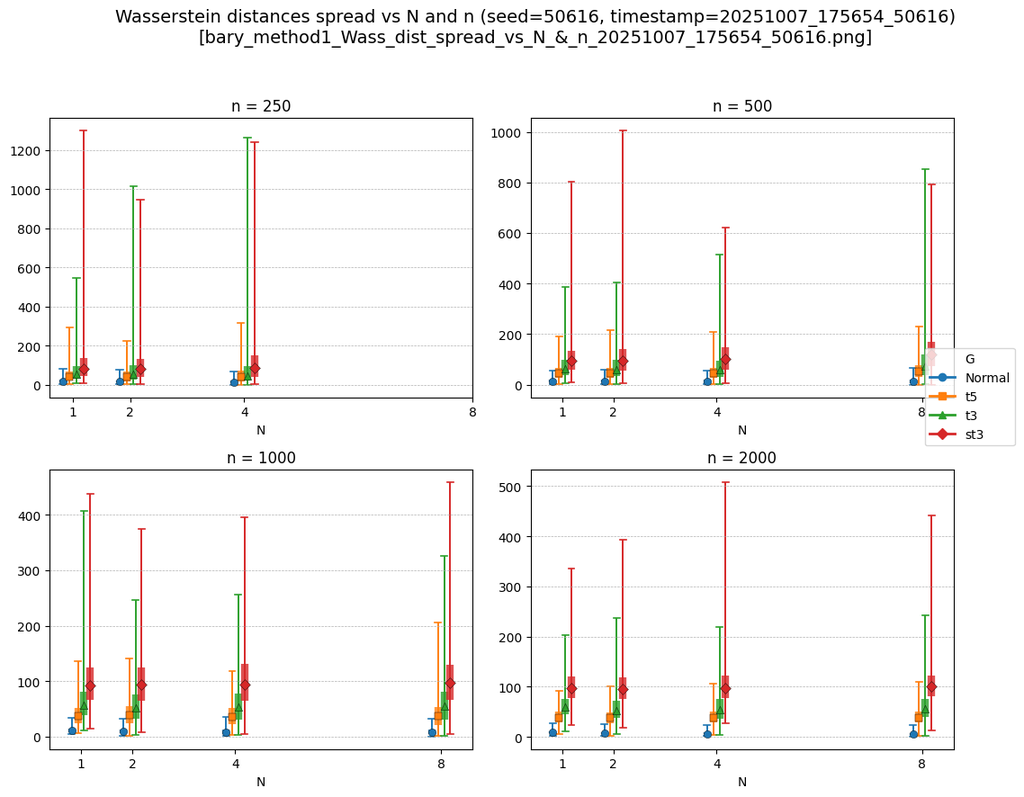

```
'bary_method1_Wass_dist_spread_vs_N_&_n_20251007_175654_50616.png'
```

```python
plot_wass_distances_spread(results_df, column_name = "W_list", filename=f"bary_method1_Wass_dist_spread_vs_N_&_n_{timestamp}.png", title= f"Wasserstein distances spread vs N and n (seed={seed}, timestamp={timestamp})")
```

# Hypothesis Testing of the Wasserstein Distances

```python
results_test = run_wasserstein_barycentre_simulations_test(f_sample = f_samples,
                                                           g_names = ['Normal', 't5', 't3', 'st3'],
                                                           N_replications=1000,
                                                           F_name="Normal",
                                                           alpha_1 = 0.975,
                                                           N_list=[1, 2, 4, 8],
                                                           n_list=[250, 500, 1000, 2000],
                                                           dist_fun = wasserstein_1d_scipy,
                                                           verbose=False,
                                                           output_type='summary',
                                                           seed=None,
                                                           B_crit=1000
                                                           )
results_test_df = pd.DataFrame(results_test)
print(results_test_df.set_index(['G', 'n', 'N']).to_string(float_format="%.4f"))

# save to csv
output_test_filename = f"results/bary_meth1_test_{timestamp}.csv"
results_test_df.to_csv(output_test_filename, index=False)
```

```
               W_bary
G      n    N
Normal 250  1  0.0580
            2  0.0420
            4  0.0460
            8  0.0000
       500  1  0.0430
            2  0.0530
            4  0.0560
            8  0.0410
       1000 1  0.0710
            2  0.0560
            4  0.0380
            8  0.0560
       2000 1  0.0680
```

[output cut: 51 more lines]

### Plot of the Hypothesis test results

y-axis denotes the $\%$ of rejections of the null hypothesis

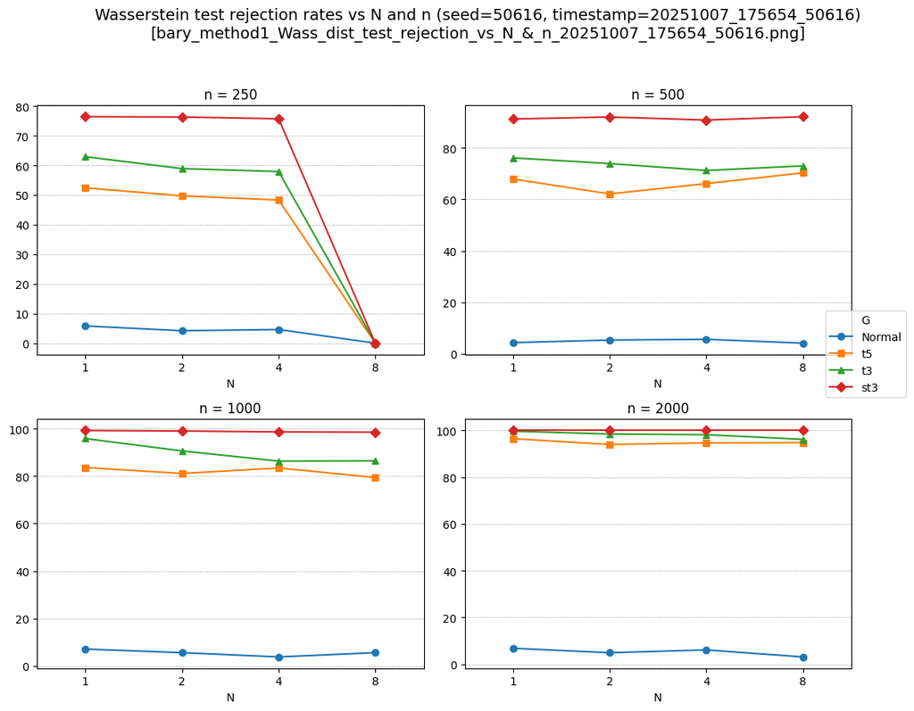

```
'bary_method1_Wass_dist_test_rejection_vs_N_&_n_20251007_175654_50616.png'
```

```python
# plot
plot_wass_distances_mean(results_test_df, ns = [250, 500, 1000, 2000], column_name="W_bary", filename=f"bary_method1_Wass_dist_test_rejection_vs_N_&_n_{timestamp}.png", title = f"Wasserstein test rejection rates vs N and n (seed={seed}, timestamp={timestamp})")
```

## Thinking about

1. (Critical) Can we do iterpolation to get the equal number of points in the incomplete bins for the barycentre calculation? Currently, if the number of data points in the bins are not equal, we only take the minimum number of points in the bins and then compute the barycentre. This is leading to loss of information.
2. Now, what if you are only given with the value of VaR levels, and not the distribution $F$
3. What will change when we move to the multivariate case
4. making the choice of $n$ flexible